# Perfume Project

Ryan Cartularo and Victoria Fuller

10/26/2021

## Brief Introduction:

Our project is to explore the Perfume dataset created by Sagi Keren, which is available here: https://www.kaggle.com/sagikeren88/fragrances-and-perfumes. Namely the goal is to look at the trends that fragrances have experienced through the years and decades.

Our dataset is a collection of the data curated on the website Fragrantica.com, which is the most popular website for perfume information by a wide margin. It collects user reviews of individual fragrances from the mid 1700s to now and also polls users about what situations those fragrances are most suited for (day, night, fall, summer, …etc). The other big bit of information it stores is the notes used in each fragrance.

```r
perfume <- perfume %>%
  select(-c('longevity_poor','longevity_weak','longevity_moderate','longevity_long','longevity_very_long', 'sillage_soft', 'sillage_moderate','sillage_heavy','sillage_enormous','clslove_female25under','clslove_male25under','clslove_female25older','clslove_male25older','clslike_female25under','clslike_male25under','clslike_female25older','clslike_male25older','clsdislike_female25under','clsdislike_male25under','clsdislike_female25older','clsdislike_male25older','clswinter_female25under','clswinter_male25under','clswinter_female25older','clswinter_male25older','clsspring_female25under','clsspring_male25under','clsspring_female25older','clsspring_male25older','clssummer_female25under','clssummer_male25under','clssummer_female25older','clssummer_male25older','clsautumn_female25under','clsautumn_male25under','clsautumn_female25older','clsautumn_male25older','clsday_female25under','clsday_male25under','clsday_female25older','clsday_male25older','clsnight_female25under','clsnight_male25under','clsnight_female25older','clsnight_male25older')) %>%
  mutate_at(vars(title, accords, notes_1,notes_2,notes_3,notes_4,notes_5,notes_6,notes_7,notes_8,notes_9,
                 notes_10,notes_11,notes_12,notes_13,notes_14,notes_15,notes_16,notes_17,notes_18,notes_19 , notes_20), ~ as.factor(.)) %>%
  filter(rating_score > 0) %>%
  filter(votes > 0) %>%
  filter(date < 2022) %>%
  filter(date > 1759) %>%
  mutate(popularity = (rating_score * votes))

perfume %>% head(20) %>% kable()
```

| …1 | title | date | accords | rating_score | votes | clslove | clslike | clsdislike | clswinter | clsspring | clssummer | clsautumn | clscold | clshot | clsday | clsnight | Ihaveit | Ihadit | Iwantit | notes_1 | notes_2 | notes_3 | notes_4 | notes_5 | notes_6 | notes_7 | notes_8 | notes_9 | notes_10 | … |
| --- | --- | --- | --- | --- | --- | --- | --- | --- | --- | --- | --- | --- | --- | --- | --- | --- | --- | --- | --- | --- | --- | --- | --- | --- | --- | --- | --- | --- | --- | --- |
| MPF | Sheikh 2020 MPF for men | 2020 | green,floral,fresh,woody,herbal | 5 | 2 | 100 | 1 | 1 | 1 | 1 | 1 | 1 | 0 | 0 | 1 | 1 | 1 | 0 | 0 | Woody Notes | Musk | Wildflowers | Herbal Notes | NA | NA | NA | NA | NA | NA | … |
| Chanel | Coromandel Parfum Chanel for women and men | 2019 | balsamic,citrus,amber,warm spicy,patchouli | 5 | 15 | 100 | 1 | 1 | 37 | 37 | 37 | 50 | 0 | 0 | 50 | 50 | 7 | 0 | 0 | Neroli | Bitter Orange | Rose | Jasmine | Orris Root | Patchouli | Olibanum | Labdanum | Benzoin | NA | … |
| WIDIAN | New York WIDIAN for women and men | 2019 | aromatic,citrus,fresh spicy,amber,balsamic,Pictures | 5 | 10 | 100 | 1 | 1 | 28 | 28 | 1 | 42 | 0 | 0 | 14 | 42 | 4 | 0 | 0 | Yellow Mandarin | Pink Pepper | Lavender | Coriander | Juniper | Geranium | Orris | Rose | Akigalawood | Jasmine | … |
| Gucci | Ode on Melancholy Perfume Oil Gucci for women and men | 2019 | woody,earthy,patchouli,balsamic,warm spicy,Pictures | 5 | 10 | 100 | 1 | 1 | 12 | 12 | 12 | 12 | 0 | 0 | 12 | 12 | 2 | 0 | 0 | Cypriol Oil or Nagarmotha | Patchouli | Sandalwood | nan | nan | NA | NA | NA | NA | NA | … |
| Acqua-di-Parma | Oud Eau de Parfum Acqua di Parma for women and men | 2019 | woody,citrus,balsamic,oud,fresh spicy,aromatic,Pictures | 5 | 9 | 100 | 1 | 1 | 71 | 28 | 14 | 57 | 0 | 0 | 14 | 85 | 2 | 0 | 0 | Calabrian bergamot | Amyris | Coriander | Agarwood (Oud) | Sandalwood | Leather | Cedar | Patchouli | Musk | NA | … |
| Jacques-Zolty | Cubata Jacques Zolty for women and men | 2019 | sweet,tobacco,honey,woody,leather | 5 | 8 | 100 | 1 | 1 | 50 | 25 | 1 | 25 | 0 | 0 | 75 | 75 | 2 | 0 | 0 | Birch | Spicy Notes | Rum | Honey | Amber | Tonka Bean | Guaiac Wood | NA | NA | NA | … |
| DSH-Perfumes | Avocado Toast DSH Perfumes for women and men | 2019 | green,sweet,floral,savory,white floral | 5 | 7 | 100 | 1 | 1 | 16 | 66 | 83 | 50 | 0 | 0 | 83 | 50 | 4 | 0 | 0 | Wheat | Sandalowood | Butter | Musk | Jasmine | Immortelle | Bulgarian Rose | Clover | nan | nan | … |
| Regalien | Clubs Of Iris Regalien for women and men | 2019 | woody,floral,citrus,powdery,ozonic,aromatic | 5 | 7 | 100 | 1 | 1 | 50 | 50 | 50 | 50 | 0 | 0 | 66 | 66 | 3 | 0 | 0 | Bergamot | Violet Leaf | Raspberry | Anise | Carnation | Orris Root | Rose | Patchouli | Cedar | Java vetiver oil | … |
| Al-Haramain-Perfumes | Amber Oud Tobacco Edition Al Haramain Perfumes for women and men | 2019 | warm spicy,sweet,tobacco,cinnamon,vanilla,Pictures | 5 | 6 | 100 | 1 | 1 | 100 | 1 | 33 | 33 | 0 | 0 | 66 | 33 | 1 | 0 | 0 | Black Pepper | Cinnamon | Tobacco Leaf | Tonka Bean | Cloves | Star Anise | Vanilla | Cacao | Incense | Dried Fruits | … |
| Les-Parfums-de-Rosine | Eloge du Vert Les Parfums de Rosine for women and men | 2019 | fresh spicy,green,aromatic,rose,woody,patchouli,Pictures | 5 | 6 | 100 | 1 | 1 | 66 | 66 | 33 | 33 | 0 | 0 | 100 | 33 | 1 | 0 | 0 | Green Pepper | Pepper | Ginger | Patchouli | Cedar | NA | NA | NA | NA | NA | … |
| Givenchy | Myrrhe Carmin Givenchy for women and men | 2019 | balsamic,fresh spicy,vanilla,rose,smoky,Pictures | 5 | 5 | 100 | 1 | 1 | 66 | 33 | 33 | 100 | 0 | 0 | 33 | 66 | 2 | 0 | 0 | Bergamot | Bulgarian Rose | Myrrh | Vanilla Absolute | Copahu Balm | Peru Balsam | NA | NA | NA | NA | … |
| Dzintars | My Charm Special Dzintars for women | 2019 | warm spicy,sweet,cinnamon,cacao,coffee,vanilla,Pictures | 5 | 5 | 100 | 1 | 1 | 1 | 1 | 1 | 1 | 0 | 0 | 1 | 1 | 2 | 0 | 0 | Coriander | Cinnamon | Saffron | Orange Blossom | Coffee | Rose | Patchouli | Tonka Bean | Vanilla | Cacao | … |
| Lucien-Ferrero-Maitre-Parfumeur | Seringa Blanc Lucien Ferrero Maitre Parfumeur for women and men | 2019 | white floral,citrus,floral,fresh,green,Pictures | 5 | 5 | 66 | 1 | 1 | 33 | 33 | 1 | 33 | 0 | 0 | 100 | 33 | 0 | 0 | 3 | Lemon Leaf | Pink Grapefruit | Tangerine Blossom | Lily Of the Valley Leaves | Syringa | Lily-of-the-Valley | White Cyclamen | Jasmine | Orange | NA | … |
| EaSTory | Vaco EaSTory for men | 2019 | woody,green,warm spicy,white floral,citrus,Videos,Pictures | 5 | 5 | 100 | 1 | 1 | 1 | 1 | 1 | 1 | 0 | 0 | 1 | 1 | 4 | 0 | 0 | Lime | Cardamom | Oakmoss | Jasmine | Woody Notes | nan | nan | NA | NA | NA | … |
| Lucien-Ferrero-Maitre-Parfumeur | Par Amour Pour Lui Lucien Ferrero Maitre Parfumeur for men | 2019 | aromatic,balsamic,woody,fresh spicy,sweet,tobacco,Pictures | 5 | 5 | 100 | 1 | 1 | 66 | 1 | 1 | 100 | 0 | 0 | 66 | 100 | 2 | 0 | 0 | Tarragon | Labdanum | Bergamot | Lavender | Leather | Tobacco | Patchouli | Styrax | Carnation leaves | Hay | … |
| Kenzo | Kenzo Homme Fresh Eau de Parfum Kenzo for men | 2019 | marine,aromatic,sweet,salty,woody,warm spicy,Pictures | 5 | 5 | 50 | 1 | 1 | 1 | 50 | 100 | 50 | 0 | 0 | 100 | 100 | 0 | 0 | 25 | Cardamom | Sea Notes | Sweet Notes | Woodsy Notes | NA | NA | NA | NA | NA | NA | … |
| Boadicea-the-Victorious | Heroine Boadicea the Victorious for women | 2019 | powdery,citrus,floral,white floral,woody,vanilla | 5 | 5 | 100 | 1 | 1 | 33 | 100 | 66 | 33 | 0 | 0 | 100 | 100 | 5 | 0 | 0 | Orange | Violet | Jasmine | Rose | Orris | Vetiver | Vanilla | Musk | NA | NA | … |
| Boadicea-the-Victorious | Lavish Boadicea the Victorious for women and men | 2019 | citrus,woody,aromatic,green,fresh spicy | 5 | 5 | 100 | 1 | 1 | 33 | 33 | 1 | 33 | 0 | 0 | 33 | 33 | 3 | 0 | 0 | Lemon | Rose | Nutmeg | Orange | Vetiver | Amber | Cedar | Sandalwood | NA | NA | … |
| Acqua-di-Sardegna | Hirvu Free Island Acqua di Sardegna for women and men | 2019 | powdery,aromatic,citrus,woody,floral,Pictures | 5 | 4 | 33 | 1 | 1 | 33 | 100 | 66 | 100 | 0 | 0 | 66 | 100 | 1 | 0 | 0 | Cardamom | Carrot Seeds | Sea Notes | Coriander | Violet | Laminaria | Dew Drop | Vetiver | Incense | Patchouli | … |
| Acqua-di-Parma | Leather Eau de Parfum Acqua di Parma for women and men | 2019 | woody,citrus,leather,sweet,fruity,rose,Pictures | 5 | 4 | 66 | 1 | 1 | 66 | 1 | 1 | 33 | 0 | 0 | 1 | 100 | 1 | 0 | 0 | Sicilian Lemon | Raspberry | Red Thyme | Honeysuckle | Petitgrain | Rose | Leather | Cedar | Guaiac Wood | NA | … |

## Columns Explained

### …1:

The Company That Produced The Perfume

### title:

The Name of The Individual Perfume

### date:

The Year The Perfume Was First Produced

### accords:

The Main categories that the perfume is filling (like “fruity” or “spicy”), can be thought of as a combination of notes

### rating_score:

A scale of 1-5 on how user’s of Fragrantica.com judge the quality of the perfume to be

### votes:

How many people have voted on this fragrance (Note: this only relates to the rating_score column)

### clslove:

Percentage of users who ‘love’ this fragrance

### clslike:

Percentage of users who ‘like’ this fragrance

### clsdislike:

Percentage of users who ‘dislike’ this fragrance

### clswinter:

Percentage of users who think this fragrance is better in the winter

### clsspring:

Percentage of users who think this fragrance is better in the spring

### clssummer:

Percentage of users who think this fragrance is better in the summer

### clsautumn:

Percentage of users who think this fragrance is better in the fall

### clscold:

of users who think this fragrance is better in cold weather

### clshot:

Percentage of users who think this fragrance is better in hot weather

### clsday:

Percentage of users who think this fragrance is better suited for daytime use

### clsnight:

Percentage of users who think this fragrance is better suited for nighttime use

### Ihaveit:

Number of users who claim to own this fragrance

### Ihadit:

Number of users who claim to have used to own the fragrance

### Iwantit:

number of users who want the fragrance

### notes_1…notes_20:

The individual elements you are supposed to be able to smell in a fragrance in descending power (so the concentration of a note will be stronger in notes_1 than notes_20)

### gender:

The gender that the fragrance is marketed towards

### popularity:

A column that we created who is the product of votes & rating_score. This is our output because it is a reasonably good predictor of the quality of a fragrance

## Basic Summary Statistics

### Summaries and Standard Deviations Of The Basic Important Columns

```r
summary(perfume$rating_score)
```

```
##    Min. 1st Qu.  Median    Mean 3rd Qu.    Max.
##   1.000   3.690   4.010   3.958   4.360   5.000
```

```r
sd(perfume$rating_score)
```

```
## [1] 0.6864676
```

```r
summary(perfume$votes)
```

```
##    Min. 1st Qu.  Median    Mean 3rd Qu.    Max.
##     1.0     9.0    29.0   345.3   199.0 11188.0
```

```r
sd(perfume$votes)
```

```
## [1] 942.8503
```

```r
summary(perfume$clslove)
```

```
##    Min. 1st Qu.  Median    Mean 3rd Qu.    Max.
##    1.00   66.00  100.00   82.18  100.00  100.00
```

```r
sd(perfume$clslove)
```

```
## [1] 28.93301
```

```r
summary(perfume$clslike)
```

```
##    Min. 1st Qu.  Median    Mean 3rd Qu.    Max.
##    1.00   33.00   63.00   59.12  100.00  100.00
```

```r
sd(perfume$clslike)
```

```
## [1] 35.463
```

```r
summary(perfume$clsdislike)
```

```
##    Min. 1st Qu.  Median    Mean 3rd Qu.    Max.
##    1.00   10.00   27.00   33.46   50.00  100.00
```

```r
sd(perfume$clsdislike)
```

```
## [1] 29.7262
```

## Additional Summary Statistics

### Additional Summaries and Standard Deviations Of The Basic Important Columns

This is the summary statistics for the more obscure columns of the dataset that still have some importance and relevance for our exploration of the data

```r
summary(perfume$clssummer)
```

```
##    Min. 1st Qu.  Median    Mean 3rd Qu.    Max.
##    1.00    4.00   12.00   19.48   28.00  100.00
```

```r
sd(perfume$clssummer)
```

```
## [1] 20.68804
```

```r
summary(perfume$clsautumn)
```

```
##    Min. 1st Qu.  Median    Mean 3rd Qu.    Max.
##    1.00   21.50   35.00   36.87   50.00  100.00
```

```r
sd(perfume$clsautumn)
```

```
## [1] 24.51354
```

```r
summary(perfume$clsspring)
```

```
##    Min. 1st Qu.  Median    Mean 3rd Qu.    Max.
##    1.00   11.00   25.00   29.23   43.00  100.00
```

```r
sd(perfume$clsspring)
```

```
## [1] 23.99186
```

```r
summary(perfume$clswinter)
```

```
##    Min. 1st Qu.  Median    Mean 3rd Qu.    Max.
##    1.00   14.00   29.00   33.05   48.00  100.00
```

```r
sd(perfume$clswinter)
```

```
## [1] 26.18174
```

```r
summary(perfume$clssday)
```

```
## Length  Class   Mode
##      0   NULL   NULL
```

```r
sd(perfume$clssday)
```

```
## [1] NA
```

```r
summary(perfume$clsnight)
```

```
##    Min. 1st Qu.  Median    Mean 3rd Qu.    Max.
##    1.00   20.00   35.00   38.59   50.00  100.00
```

```r
sd(perfume$clsnight)
```

```
## [1] 26.97896
```

```r
summary(perfume$clsspring)
```

```
##    Min. 1st Qu.  Median    Mean 3rd Qu.    Max.
##    1.00   11.00   25.00   29.23   43.00  100.00
```

```r
sd(perfume$clsspring)
```

```
## [1] 23.99186
```

```r
summary(perfume$Ihaveit)
```

```
##    Min. 1st Qu.  Median    Mean 3rd Qu.    Max.
##     0.0     5.0    18.0   240.3   170.5  6226.0
```

```r
sd(perfume$Ihaveit)
```

```
## [1] 599.5955
```

```r
summary(perfume$Ihadit)
```

```
##     Min.  1st Qu.   Median     Mean  3rd Qu.     Max.
## 0.000000 0.000000 0.000000 0.005964 0.000000 1.000000
```

```r
sd(perfume$Ihadit)
```

```
## [1] 0.07707433
```

```r
summary(perfume$Iwantit)
```

```
##    Min. 1st Qu.  Median    Mean 3rd Qu.    Max.
##   0.000   0.000   0.000   0.501   0.000  46.000
```

```r
sd(perfume$Iwantit)
```

```
## [1] 3.222107
```

## Our Summary Statistics

### Our Summaries and Standard Deviations Of The Basic Important Columns

These summary statistics are for the columns that we created. At the moment, the only new column we think necessary is the creation of a “popularity” column that is the product of the rating_score and votes columns. We felt this was a more accurate predictor of the overall quality of a perfume since there are several perfumes with perfect ratings of ‘5’ but only one or two votes.

```r
summary(perfume$popularity)
```

```
##    Min. 1st Qu.  Median    Mean 3rd Qu.    Max.
##     1.0    36.0   118.8  1283.6   833.5 35242.2
```

```r
sd(perfume$popularity)
```

```
## [1] 3330.843
```

## Our Graphs

### Density Plot of rating_score

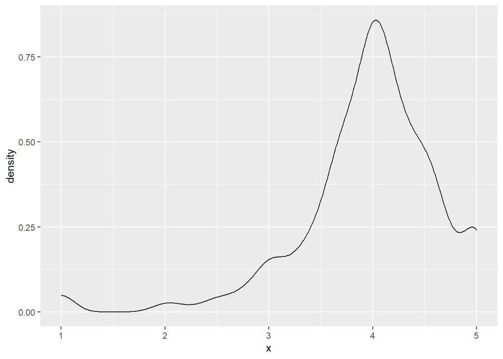

```r
ggplot(tibble(x=perfume$rating_score)) + geom_density(aes(x=x))
```

### Scatter Plot of rating_score vs votes

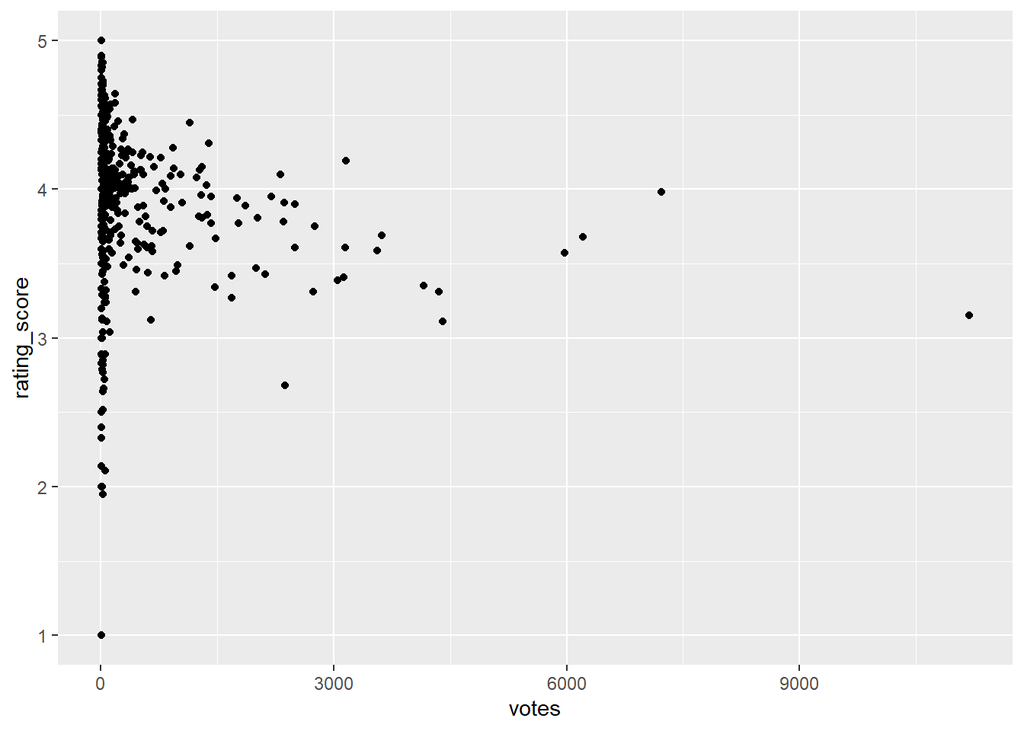

```r
ggplot(perfume) + geom_point(aes(x=votes,y=rating_score))
```

### Histogram of rating_score

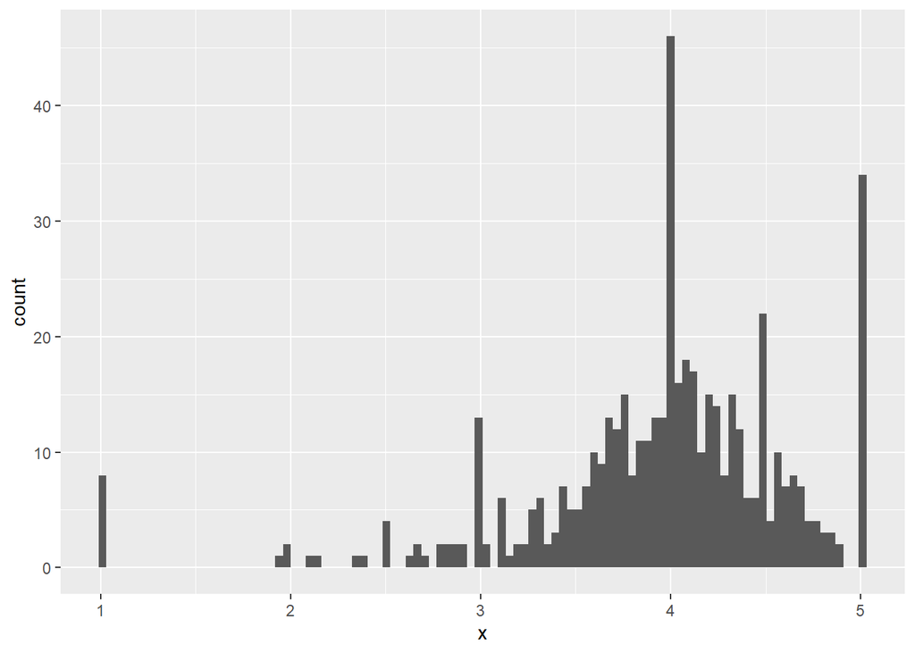

```r
ggplot(tibble(x=perfume$rating_score)) + geom_histogram(aes(x=x),bins=100)
```

### Histogram of rating_score That Includes Gender

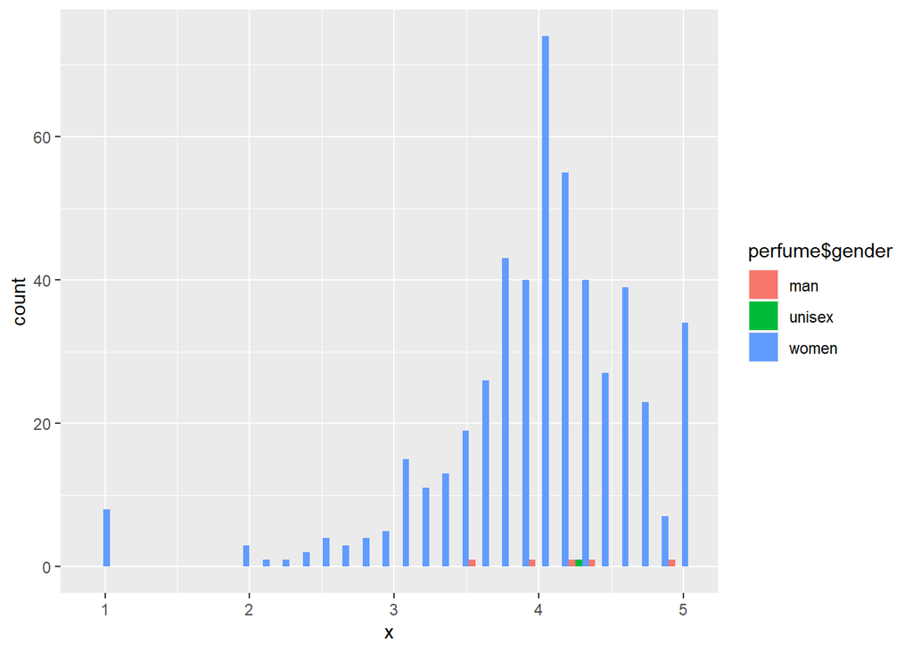

```r
ggplot(tibble(x=perfume$rating_score)) + geom_histogram(aes(x=x, fill=perfume$gender), position='dodge')
```

### Density Plot of Votes

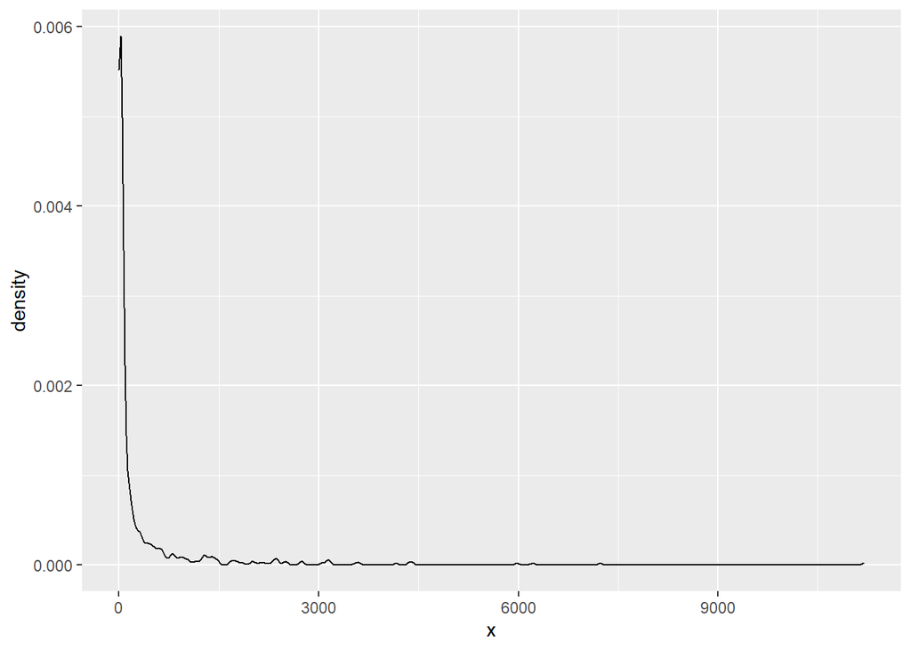

```r
ggplot(tibble(x=perfume$votes)) + geom_density(aes(x=x))
```

### Histogram of Votes

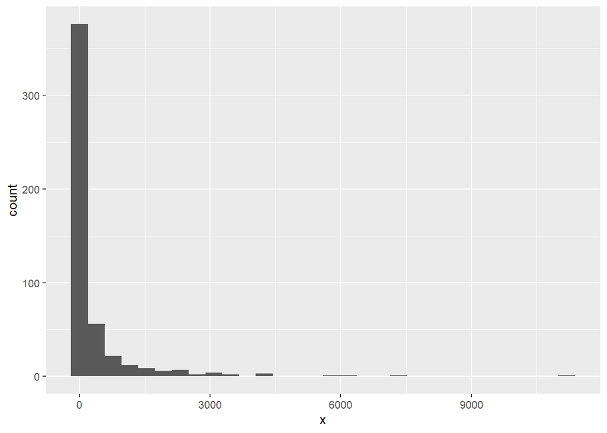

```r
ggplot(tibble(x=perfume$votes)) + geom_histogram(aes(x=x))
```

### Histogram of clslove

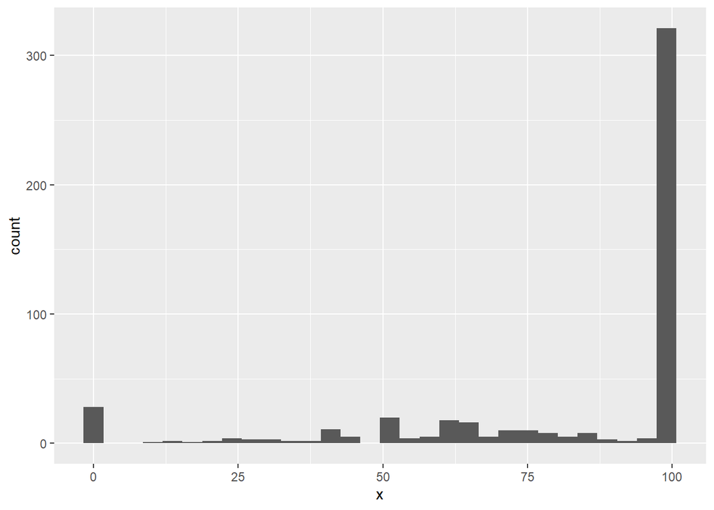

```r
ggplot(tibble(x=perfume$clslove)) + geom_histogram(aes(x=x))
```

### Histogram of clslike

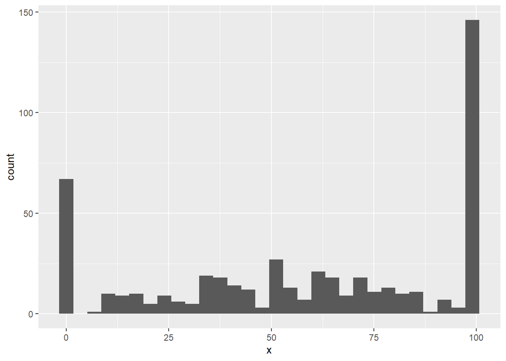

```r
ggplot(tibble(x=perfume$clslike)) + geom_histogram(aes(x=x))
```

### Histogram of clsdislike

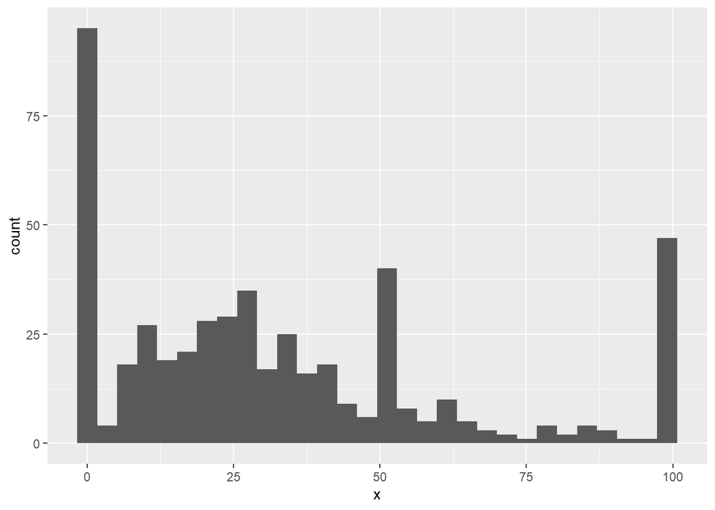

```r
ggplot(tibble(x=perfume$clsdislike)) + geom_histogram(aes(x=x))
```

### Histogram of popularity

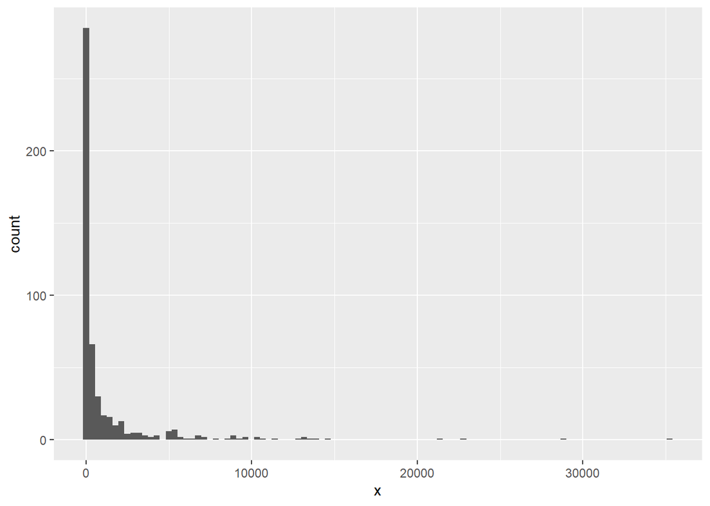

```r
ggplot(tibble(x=perfume$popularity)) + geom_histogram(aes(x=x), bins=100)
```

### Histogram of date

We have adjusted the bins of the two graphs below so that the first graph displays a bar for each individual year of perfume history, which we judge to start in 1760 with The House of Creed’s: ‘Royal Service’. The second graph displays a bar for each decade of perfume history

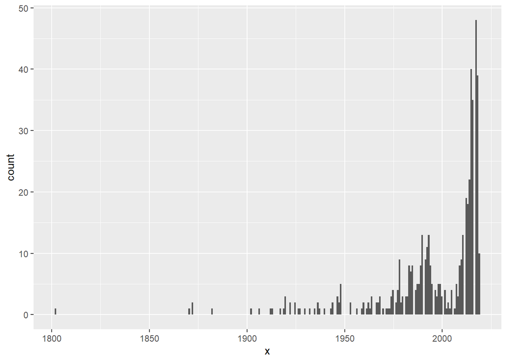

```r
ggplot(tibble(x=perfume$date)) + geom_histogram(aes(x=x), bins=261)
```

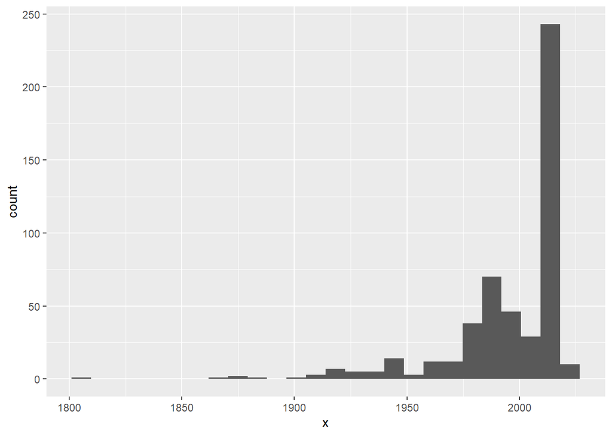

```r
ggplot(tibble(x=perfume$date)) + geom_histogram(aes(x=x), bins=26)
```

### Bar Plot of date vs popularity

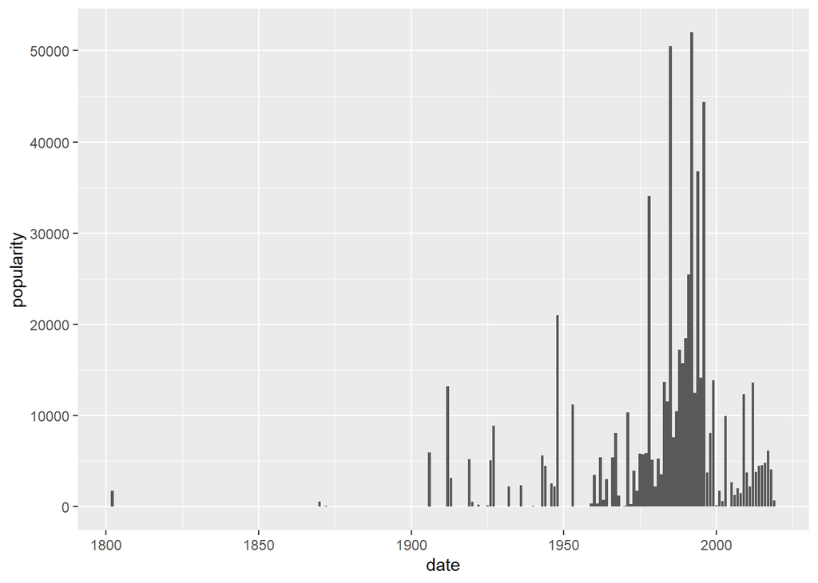

```r
ggplot(perfume) + geom_col(aes(x=date,y=popularity))
```

## Creating A Basic Model

```r
model.complete <- lm(popularity ~ notes_1 + notes_2 + notes_3 + notes_4 + notes_5 + notes_6 + notes_7 + notes_8 + notes_9 + notes_10 + notes_11 + notes_12 + notes_13 + notes_14 + notes_15 + notes_16 + notes_17 + notes_18 + notes_19 + notes_20, perfume)
```

## Using Stepwise Regression To Make Our Final Model For The Popularity Of All Perfume

```r
suppressWarnings(ols_step_both_aic(model.complete, details=TRUE))
```

```
## Stepwise Selection Method
## -------------------------
##
## Candidate Terms:
##
## 1 . notes_1
## 2 . notes_2
## 3 . notes_3
## 4 . notes_4
## 5 . notes_5
## 6 . notes_6
## 7 . notes_7
## 8 . notes_8
## 9 . notes_9
## 10 . notes_10
## 11 . notes_11
## 12 . notes_12
## 13 . notes_13
## 14 . notes_14
## 15 . notes_15
## 16 . notes_16
## 17 . notes_17
## 18 . notes_18
## 19 . notes_19
## 20 . notes_20
##
##  Step 0: AIC = 589158.5
##  popularity ~ 1
##
##
## Variables Entered/Removed:
##
##                                    Enter New Variables
## ----------------------------------------------------------------------------------------
## Variable     DF       AIC            Sum Sq              RSS          R-Sq     Adj. R-Sq
## ----------------------------------------------------------------------------------------
## notes_3       1    561852.671    4461877818.545    89929857689.101    0.047        0.019
## notes_5       1    498226.214    4210993609.923    86518885413.943    0.046        0.017
## notes_12      1    104578.408    3910319095.640    30953402015.289    0.112        0.020
## notes_9       1    243961.224    3574587974.127    58241482131.769    0.058        0.015
```

[output cut: 1173 more lines]

```
##                    notes_12Tobacco      -7160.022             NA        0.288        NA       NA     -163928.458     149608.415
##                 notes_12Tonka Bean     -54586.814             NA        0.372        NA       NA     -492550.771     383377.143
##                   notes_12Tuberose             NA             NA        2.056        NA       NA              NA             NA
##               notes_12Turkish Rose             NA             NA        0.223        NA       NA              NA             NA
##                    notes_12Vanilla             NA             NA        1.143        NA       NA              NA             NA
##                    notes_12Vetiver             NA             NA        1.290        NA       NA              NA             NA
##                     notes_12Violet             NA             NA        2.788        NA       NA              NA             NA
##                notes_12Violet Leaf             NA             NA        0.073        NA       NA              NA             NA
##             notes_12Virginia Cedar             NA             NA        0.247        NA       NA              NA             NA
##            notes_12Virginian Cedar             NA             NA       -1.470        NA       NA              NA             NA
##                 notes_12Watermelon             NA             NA        0.215        NA       NA              NA             NA
##               notes_12Woodsy Notes             NA             NA        0.726        NA       NA              NA             NA
##             notes_12Yellow Freesia             NA             NA        0.454        NA       NA              NA             NA
##                notes_12Ylang-Ylang             NA             NA        9.316        NA       NA              NA             NA
## --------------------------------------------------------------------------------------------------------------------------------
```

```
##
##
##                                        Stepwise Summary
## ---------------------------------------------------------------------------------------------
## Variable     Method        AIC            RSS              Sum Sq         R-Sq      Adj. R-Sq
## ---------------------------------------------------------------------------------------------
## notes_20    addition    13092.736    6742863124.044    1591767461.819    0.19098     -0.11302
## notes_9     addition    12992.821    3337371194.651    4997259391.212    0.59958      0.17705
## notes_5     addition    12947.291    1801995166.571    6532635419.292    0.78379      0.24553
## notes_7     addition    12800.450     856813791.488    7477816794.375    0.89720      0.18968
## notes_12    addition    12635.636     342734230.477    7991896355.385    0.95888     -0.53064
## ---------------------------------------------------------------------------------------------
```

### Successful Notes: Orange, Hyacinth, Black Pepper, Verbena, Mint

### Unsuccessful Notes: Vetiver, Saffron, Nectarine, Lily of The Valley

## Making a Basic Model For Each Important Decade Of Perfumery

```r
perfume70 <- perfumeuse %>%
  select(-c('longevity_poor','longevity_weak','longevity_moderate','longevity_long','longevity_very_long', 'sillage_soft', 'sillage_moderate','sillage_heavy','sillage_enormous','clslove_female25under','clslove_male25under','clslove_female25older','clslove_male25older','clslike_female25under','clslike_male25under','clslike_female25older','clslike_male25older','clsdislike_female25under','clsdislike_male25under','clsdislike_female25older','clsdislike_male25older','clswinter_female25under','clswinter_male25under','clswinter_female25older','clswinter_male25older','clsspring_female25under','clsspring_male25under','clsspring_female25older','clsspring_male25older','clssummer_female25under','clssummer_male25under','clssummer_female25older','clssummer_male25older','clsautumn_female25under','clsautumn_male25under','clsautumn_female25older','clsautumn_male25older','clsday_female25under','clsday_male25under','clsday_female25older','clsday_male25older','clsnight_female25under','clsnight_male25under','clsnight_female25older','clsnight_male25older')) %>%
  mutate_at(vars(title, accords, notes_1,notes_2,notes_3,notes_4,notes_5,notes_6,notes_7,notes_8,notes_9,
                 notes_10,notes_11,notes_12,notes_13,notes_14,notes_15,notes_16,notes_17,notes_18,notes_19 , notes_20), ~ as.factor(.)) %>%
  filter(rating_score > 0) %>%
  filter(votes > 0) %>%
  filter(date < 1980) %>%
  filter(date > 1970) %>%
  mutate(popularity70 = (rating_score * votes))

perfume80 <- perfumeuse %>%
  select(-c('longevity_poor','longevity_weak','longevity_moderate','longevity_long','longevity_very_long', 'sillage_soft', 'sillage_moderate','sillage_heavy','sillage_enormous','clslove_female25under','clslove_male25under','clslove_female25older','clslove_male25older','clslike_female25under','clslike_male25under','clslike_female25older','clslike_male25older','clsdislike_female25under','clsdislike_male25under','clsdislike_female25older','clsdislike_male25older','clswinter_female25under','clswinter_male25under','clswinter_female25older','clswinter_male25older','clsspring_female25under','clsspring_male25under','clsspring_female25older','clsspring_male25older','clssummer_female25under','clssummer_male25under','clssummer_female25older','clssummer_male25older','clsautumn_female25under','clsautumn_male25under','clsautumn_female25older','clsautumn_male25older','clsday_female25under','clsday_male25under','clsday_female25older','clsday_male25older','clsnight_female25under','clsnight_male25under','clsnight_female25older','clsnight_male25older')) %>%
  mutate_at(vars(title, accords, notes_1,notes_2,notes_3,notes_4,notes_5,notes_6,notes_7,notes_8,notes_9,
                 notes_10,notes_11,notes_12,notes_13,notes_14,notes_15,notes_16,notes_17,notes_18,notes_19 , notes_20), ~ as.factor(.)) %>%
  filter(rating_score > 0) %>%
  filter(votes > 0) %>%
  filter(date < 1990) %>%
  filter(date > 1980) %>%
  mutate(popularity80 = (rating_score * votes))

perfume90 <- perfumeuse %>%
  select(-c('longevity_poor','longevity_weak','longevity_moderate','longevity_long','longevity_very_long', 'sillage_soft', 'sillage_moderate','sillage_heavy','sillage_enormous','clslove_female25under','clslove_male25under','clslove_female25older','clslove_male25older','clslike_female25under','clslike_male25under','clslike_female25older','clslike_male25older','clsdislike_female25under','clsdislike_male25under','clsdislike_female25older','clsdislike_male25older','clswinter_female25under','clswinter_male25under','clswinter_female25older','clswinter_male25older','clsspring_female25under','clsspring_male25under','clsspring_female25older','clsspring_male25older','clssummer_female25under','clssummer_male25under','clssummer_female25older','clssummer_male25older','clsautumn_female25under','clsautumn_male25under','clsautumn_female25older','clsautumn_male25older','clsday_female25under','clsday_male25under','clsday_female25older','clsday_male25older','clsnight_female25under','clsnight_male25under','clsnight_female25older','clsnight_male25older')) %>%
  mutate_at(vars(title, accords, notes_1,notes_2,notes_3,notes_4,notes_5,notes_6,notes_7,notes_8,notes_9,
                 notes_10,notes_11,notes_12,notes_13,notes_14,notes_15,notes_16,notes_17,notes_18,notes_19 , notes_20), ~ as.factor(.)) %>%
  filter(rating_score > 0) %>%
  filter(votes > 0) %>%
  filter(date < 2000) %>%
  filter(date > 1990) %>%
  mutate(popularity90 = (rating_score * votes))

perfume200 <- perfumeuse %>%
  select(-c('longevity_poor','longevity_weak','longevity_moderate','longevity_long','longevity_very_long', 'sillage_soft', 'sillage_moderate','sillage_heavy','sillage_enormous','clslove_female25under','clslove_male25under','clslove_female25older','clslove_male25older','clslike_female25under','clslike_male25under','clslike_female25older','clslike_male25older','clsdislike_female25under','clsdislike_male25under','clsdislike_female25older','clsdislike_male25older','clswinter_female25under','clswinter_male25under','clswinter_female25older','clswinter_male25older','clsspring_female25under','clsspring_male25under','clsspring_female25older','clsspring_male25older','clssummer_female25under','clssummer_male25under','clssummer_female25older','clssummer_male25older','clsautumn_female25under','clsautumn_male25under','clsautumn_female25older','clsautumn_male25older','clsday_female25under','clsday_male25under','clsday_female25older','clsday_male25older','clsnight_female25under','clsnight_male25under','clsnight_female25older','clsnight_male25older')) %>%
  mutate_at(vars(title, accords, notes_1,notes_2,notes_3,notes_4,notes_5,notes_6,notes_7,notes_8,notes_9,
                 notes_10,notes_11,notes_12,notes_13,notes_14,notes_15,notes_16,notes_17,notes_18,notes_19 , notes_20), ~ as.factor(.)) %>%
  filter(rating_score > 0) %>%
  filter(votes > 0) %>%
  filter(date < 2010) %>%
  filter(date > 2000) %>%
  mutate(popularity200 = (rating_score * votes))

perfume210 <- perfumeuse %>%
  select(-c('longevity_poor','longevity_weak','longevity_moderate','longevity_long','longevity_very_long', 'sillage_soft', 'sillage_moderate','sillage_heavy','sillage_enormous','clslove_female25under','clslove_male25under','clslove_female25older','clslove_male25older','clslike_female25under','clslike_male25under','clslike_female25older','clslike_male25older','clsdislike_female25under','clsdislike_male25under','clsdislike_female25older','clsdislike_male25older','clswinter_female25under','clswinter_male25under','clswinter_female25older','clswinter_male25older','clsspring_female25under','clsspring_male25under','clsspring_female25older','clsspring_male25older','clssummer_female25under','clssummer_male25under','clssummer_female25older','clssummer_male25older','clsautumn_female25under','clsautumn_male25under','clsautumn_female25older','clsautumn_male25older','clsday_female25under','clsday_male25under','clsday_female25older','clsday_male25older','clsnight_female25under','clsnight_male25under','clsnight_female25older','clsnight_male25older')) %>%
  mutate_at(vars(title, accords, notes_1,notes_2,notes_3,notes_4,notes_5,notes_6,notes_7,notes_8,notes_9,
                 notes_10,notes_11,notes_12,notes_13,notes_14,notes_15,notes_16,notes_17,notes_18,notes_19 , notes_20), ~ as.factor(.)) %>%
  filter(rating_score > 0) %>%
  filter(votes > 0) %>%
  filter(date < 2020) %>%
  filter(date > 2010) %>%
  mutate(popularity210 = (rating_score * votes))


model.complete70 <- lm(popularity70 ~ notes_1 + notes_2 + notes_3 + notes_4 + notes_5 + notes_6 + notes_7 + notes_8 + notes_9 + notes_10 + notes_11 + notes_12 + notes_13 + notes_14 + notes_15 + notes_16 + notes_17 + notes_18 + notes_19 + notes_20, perfume70)

model.complete80 <- lm(popularity80 ~ notes_1 + notes_2 + notes_3 + notes_4 + notes_5 + notes_6 + notes_7 + notes_8 + notes_9 + notes_10 + notes_11 + notes_12 + notes_13 + notes_14 + notes_15 + notes_16 + notes_17 + notes_18 + notes_19 + notes_20, perfume80)

model.complete90 <- lm(popularity90 ~ notes_1 + notes_2 + notes_3 + notes_4 + notes_5 + notes_6 + notes_7 + notes_8 + notes_9 + notes_10 + notes_11 + notes_12 + notes_13 + notes_14 + notes_15 + notes_16 + notes_17 + notes_18 + notes_19 + notes_20, perfume90)

model.complete200 <- lm(popularity200 ~ notes_1 + notes_2 + notes_3 + notes_4 + notes_5 + notes_6 + notes_7 + notes_8 + notes_9 + notes_10 + notes_11 + notes_12 + notes_13 + notes_14 + notes_15 + notes_16 + notes_17 + notes_18 + notes_19 + notes_20, perfume200)

model.complete210 <- lm(popularity210 ~ notes_1 + notes_2 + notes_3 + notes_4 + notes_5 + notes_6 + notes_7 + notes_8 + notes_9 + notes_10 + notes_11 + notes_12 + notes_13 + notes_14 + notes_15 + notes_16 + notes_17 + notes_18 + notes_19 + notes_20, perfume210)
```

# Using Stepwise Regression To Make Our Final Model For The Popularity For Each Decade In The Modern Era

## The 1970s

```r
suppressWarnings(ols_step_both_aic(model.complete70, details=TRUE))
```

```
## Stepwise Selection Method
## -------------------------
##
## Candidate Terms:
##
## 1 . notes_1
## 2 . notes_2
## 3 . notes_3
## 4 . notes_4
## 5 . notes_5
## 6 . notes_6
## 7 . notes_7
## 8 . notes_8
## 9 . notes_9
## 10 . notes_10
## 11 . notes_11
## 12 . notes_12
## 13 . notes_13
## 14 . notes_14
## 15 . notes_15
## 16 . notes_16
## 17 . notes_17
## 18 . notes_18
## 19 . notes_19
## 20 . notes_20
##
##  Step 0: AIC = 7335.524
##  popularity70 ~ 1
##
##
## Variables Entered/Removed:
##
##                                  Enter New Variables
## -----------------------------------------------------------------------------------
## Variable     DF      AIC          Sum Sq             RSS         R-Sq     Adj. R-Sq
## -----------------------------------------------------------------------------------
## notes_4       1    6629.690    432193513.983    560518713.944    0.435        0.158
## notes_9       1    4061.345    385998875.957    446095904.281    0.464        0.222
## notes_1       1    7381.001    361877832.281    652089227.805    0.357        0.112
## notes_5       1    6284.304    360486376.905    615194771.694    0.369        0.045
```

[output cut: 168 more lines]

```
##             notes_17Caraway           NA            NA        0.422     NA      NA      NaN      NaN
##               notes_17Cedar           NA            NA        0.005     NA      NA      NaN      NaN
##            notes_17Geranium           NA            NA       -0.001     NA      NA      NaN      NaN
##            notes_17Labdanum           NA            NA        0.003     NA      NA      NaN      NaN
##            notes_17Lavender           NA            NA        0.010     NA      NA      NaN      NaN
##  notes_17Lily-of-the-Valley           NA            NA        0.056     NA      NA      NaN      NaN
##                notes_17Musk           NA            NA        0.318     NA      NA      NaN      NaN
##             notes_17Oakmoss           NA            NA        0.156     NA      NA      NaN      NaN
##           notes_17Patchouli           NA            NA        0.523     NA      NA      NaN      NaN
##                notes_17Rose           NA            NA        0.052     NA      NA      NaN      NaN
##          notes_17Sandalwood           NA            NA        0.281     NA      NA      NaN      NaN
##        notes_17Turkish Rose           NA            NA        0.062     NA      NA      NaN      NaN
##             notes_17Vetiver           NA            NA        0.050     NA      NA      NaN      NaN
##         notes_17Ylang-Ylang           NA            NA        0.011     NA      NA      NaN      NaN
## -----------------------------------------------------------------------------------------------------
```

```
##
##
##                                      Stepwise Summary
## ----------------------------------------------------------------------------------------
## Variable     Method       AIC          RSS            Sum Sq         R-Sq      Adj. R-Sq
## ----------------------------------------------------------------------------------------
## notes_20    addition    590.954    43800821.571    328356353.352    0.88231      0.59461
## notes_17    addition       -Inf           0.000    372157174.923    1.00000          NaN
## NA          NA             -Inf           0.000    372157174.923    1.00000          NaN
## ----------------------------------------------------------------------------------------
```

### Successful Notes: Hyacinth, Tobacco, Honey, Cedar

### Unsuccessful Notes: Oakmoss, Civet, Cinnamon, Vanilla

## The 1980s

```r
suppressWarnings(ols_step_both_aic(model.complete80, details=TRUE))
```

```
## Stepwise Selection Method
## -------------------------
##
## Candidate Terms:
##
## 1 . notes_1
## 2 . notes_2
## 3 . notes_3
## 4 . notes_4
## 5 . notes_5
## 6 . notes_6
## 7 . notes_7
## 8 . notes_8
## 9 . notes_9
## 10 . notes_10
## 11 . notes_11
## 12 . notes_12
## 13 . notes_13
## 14 . notes_14
## 15 . notes_15
## 16 . notes_16
## 17 . notes_17
## 18 . notes_18
## 19 . notes_19
## 20 . notes_20
##
##  Step 0: AIC = 13807.63
##  popularity80 ~ 1
##
##
## Variables Entered/Removed:
##
##                                   Enter New Variables
## --------------------------------------------------------------------------------------
## Variable     DF       AIC           Sum Sq             RSS          R-Sq     Adj. R-Sq
## --------------------------------------------------------------------------------------
## notes_2       1    13718.952    2208437861.057    3006278419.066    0.424        0.265
## notes_6       1    10973.493    1822281102.266    2947440164.275    0.382        0.202
## notes_4       1    12691.834    1698501648.774    3465444154.425    0.329        0.131
## notes_8       1     9386.741    1563070302.371    3116839558.661    0.334        0.113
```

[output cut: 246 more lines]

```
##             notes_7Neroli            NA            NA       -0.331        NA       NA             NA            NA
##             notes_7Nutmeg     19742.180            NA       -0.304        NA       NA    -216570.010    256054.370
##     notes_7Orange Blossom     23548.680            NA       -0.186        NA       NA    -317538.586    364635.946
##             notes_7Orchid     13077.380            NA       -0.117        NA       NA    -223234.810    249389.570
##         notes_7Orris Root     15032.830            NA        0.270        NA       NA    -230928.695    260994.355
##          notes_7Osmanthus            NA            NA       -0.592        NA       NA             NA            NA
##          notes_7Pine Tree      1286.100            NA        0.267        NA       NA    -151252.763    153824.963
##          notes_7Pineapple            NA            NA        0.051        NA       NA             NA            NA
##               notes_7Rose      9962.090            NA        0.307        NA       NA    -170524.326    190448.506
##               notes_7Sage            NA            NA       -0.123        NA       NA             NA            NA
##         notes_7Sandalwood            NA            NA        0.081        NA       NA             NA            NA
##             notes_7Spices     27230.370            NA       -0.230        NA       NA    -209081.820    263542.560
##           notes_7Tuberose            NA            NA        0.115        NA       NA             NA            NA
##        notes_7Ylang-Ylang            NA            NA       -0.112        NA       NA             NA            NA
## -------------------------------------------------------------------------------------------------------------------
```

```
##
##
##                                        Stepwise Summary
## --------------------------------------------------------------------------------------------
## Variable     Method       AIC            RSS              Sum Sq         R-Sq      Adj. R-Sq
## --------------------------------------------------------------------------------------------
## notes_20    addition    1732.341    1249504546.171     394064546.580    0.23976     -0.24270
## notes_9     addition    1602.812     122780849.100    1520788243.650    0.92530      0.68251
## notes_7     addition    1488.572      14412167.784    1629156924.966    0.99123      0.25465
## --------------------------------------------------------------------------------------------
```

### Successful Notes: Fir, Heliotrope, Geranium, Lily of The Valley, Neroli, Spices

### Unsuccessful Notes: Thyme, Sage, Sandalwood, Benzoin, Coconut

## The 1990s

```r
suppressWarnings(ols_step_both_aic(model.complete90, details=TRUE))
```

```
## Stepwise Selection Method
## -------------------------
##
## Candidate Terms:
##
## 1 . notes_1
## 2 . notes_2
## 3 . notes_3
## 4 . notes_4
## 5 . notes_5
## 6 . notes_6
## 7 . notes_7
## 8 . notes_8
## 9 . notes_9
## 10 . notes_10
## 11 . notes_11
## 12 . notes_12
## 13 . notes_13
## 14 . notes_14
## 15 . notes_15
## 16 . notes_16
## 17 . notes_17
## 18 . notes_18
## 19 . notes_19
## 20 . notes_20
##
##  Step 0: AIC = 31777.81
##  popularity90 ~ 1
##
##
## Variables Entered/Removed:
##
##                                    Enter New Variables
## ---------------------------------------------------------------------------------------
## Variable     DF       AIC           Sum Sq              RSS          R-Sq     Adj. R-Sq
## ---------------------------------------------------------------------------------------
## notes_9       1    18415.498    4102954310.239    10069668781.906    0.289        0.130
## notes_10      1    16063.215    3818334073.531    10082671615.407    0.275        0.067
## notes_11      1    13823.143    3790957474.299     9334669378.277    0.289        0.085
## notes_12      1    11519.875    3579372919.344     8971912448.143    0.285        0.089
```

[output cut: 275 more lines]

```
##                notes_11Orchid      1379.405            NA       -0.336         NA       NA     -7695.087     10453.897
##            notes_11Orris Root      -153.530            NA        0.035         NA       NA     -4502.334      4195.274
##                 notes_11Peach            NA            NA        0.202         NA       NA            NA            NA
##                notes_11Pepper      4799.710            NA        0.119         NA       NA     -1843.197     11442.617
##                  notes_11Plum        36.025            NA       -1.099         NA       NA     -7093.228      7165.278
##                 notes_11Poppy            NA            NA       -0.164         NA       NA            NA            NA
##                  notes_11Rose       362.615            NA        0.138         NA       NA     -5787.522      6512.752
##              notes_11Rosemary            NA            NA        0.081         NA       NA            NA            NA
##              notes_11Tarragon     -1718.100            NA        0.082         NA       NA    -14240.591     10804.391
##              notes_11Tuberose            NA            NA        0.015         NA       NA            NA            NA
##                notes_11Violet            NA            NA        0.029         NA       NA            NA            NA
##            notes_11Water Lily            NA            NA        0.120         NA       NA            NA            NA
##       notes_11West Indian Bay            NA            NA        0.157         NA       NA            NA            NA
##           notes_11Ylang-Ylang            NA            NA       -0.118         NA       NA            NA            NA
## -----------------------------------------------------------------------------------------------------------------------
```

```
##
##
##                                        Stepwise Summary
## --------------------------------------------------------------------------------------------
## Variable     Method       AIC            RSS              Sum Sq         R-Sq      Adj. R-Sq
## --------------------------------------------------------------------------------------------
## notes_20    addition    2069.204         2.654e+09    1416557696.381    0.34800     -0.02457
## notes_8     addition    1918.509     207862471.818    3862694927.437    0.94894      0.77021
## notes_11    addition    1685.020       8347636.489    4062209762.766    0.99795      0.95940
## --------------------------------------------------------------------------------------------
```

### Successful Notes: Benzoin, Coffee, Green Notes, Black Currant, Datura, Caraway

### Unsuccessfulr Notes: Pink Pepper, Ebony Wood, Tomato Leaf, Tonka Bean, Balsam Fir

## The 2000s

```r
suppressWarnings(ols_step_both_aic(model.complete200, details=TRUE))
```

```
## Stepwise Selection Method
## -------------------------
##
## Candidate Terms:
##
## 1 . notes_1
## 2 . notes_2
## 3 . notes_3
## 4 . notes_4
## 5 . notes_5
## 6 . notes_6
## 7 . notes_7
## 8 . notes_8
## 9 . notes_9
## 10 . notes_10
## 11 . notes_11
## 12 . notes_12
## 13 . notes_13
## 14 . notes_14
## 15 . notes_15
## 16 . notes_16
## 17 . notes_17
## 18 . notes_18
## 19 . notes_19
## 20 . notes_20
##
##  Step 0: AIC = 126049.8
##  popularity200 ~ 1
##
##
## Variables Entered/Removed:
##
##                                    Enter New Variables
## ----------------------------------------------------------------------------------------
## Variable     DF       AIC            Sum Sq              RSS          R-Sq     Adj. R-Sq
## ----------------------------------------------------------------------------------------
## notes_3       1    121928.590    5659311091.066    36561586161.788    0.134        0.065
## notes_2       1    126258.349    5025704438.542    38975772082.145    0.114        0.041
## notes_6       1     99245.651    4096938529.943    33606817331.674    0.109        0.027
## notes_5       1    110043.943    4023348957.777    36671347743.688    0.099        0.023
```

[output cut: 168 more lines]

```
##           notes_7Lavender      258.370            NA        0.000     NA      NA      NaN      NaN
##              notes_7Lemon     8157.410            NA        0.056     NA      NA      NaN      NaN
## notes_7Lily-of-the-Valley    -1101.320            NA        0.005     NA      NA      NaN      NaN
##           notes_7Magnolia           NA            NA       -0.412     NA      NA      NaN      NaN
##             notes_7Neroli      809.820            NA        0.009     NA      NA      NaN      NaN
##           notes_7Olibanum     9364.570            NA        0.066     NA      NA      NaN      NaN
##     notes_7Orange Blossom     3623.820            NA        0.079     NA      NA      NaN      NaN
##          notes_7Osmanthus           NA            NA        0.011     NA      NA      NaN      NaN
##            notes_7Paprika     -315.000            NA        0.000     NA      NA      NaN      NaN
##              notes_7Peony           NA            NA        0.000     NA      NA      NaN      NaN
##             notes_7Pepper           NA            NA        0.017     NA      NA      NaN      NaN
##         notes_7Sandalwood           NA            NA        0.010     NA      NA      NaN      NaN
##           notes_7Tuberose           NA            NA        0.049     NA      NA      NaN      NaN
##    notes_7West Indian Bay           NA            NA        0.082     NA      NA      NaN      NaN
## ---------------------------------------------------------------------------------------------------
```

```
##
##
##                                      Stepwise Summary
## -----------------------------------------------------------------------------------------
## Variable     Method       AIC           RSS            Sum Sq         R-Sq      Adj. R-Sq
## -----------------------------------------------------------------------------------------
## notes_20    addition    897.500    364205284.042    137954642.423    0.27472     -0.67959
## notes_7     addition       -Inf            0.000    502159926.465    1.00000          NaN
## -----------------------------------------------------------------------------------------
```

### Successful Notes: Bergamot, Brazillian Rosewood, Cinnamon, Iris

### Unsuccessful Notes: Leather, Lily of The Valley, Grass, Tonka Bean

## The 2010s

```r
suppressWarnings(ols_step_both_aic(model.complete210, details=TRUE))
```

```
## Stepwise Selection Method
## -------------------------
##
## Candidate Terms:
##
## 1 . notes_1
## 2 . notes_2
## 3 . notes_3
## 4 . notes_4
## 5 . notes_5
## 6 . notes_6
## 7 . notes_7
## 8 . notes_8
## 9 . notes_9
## 10 . notes_10
## 11 . notes_11
## 12 . notes_12
## 13 . notes_13
## 14 . notes_14
## 15 . notes_15
## 16 . notes_16
## 17 . notes_17
## 18 . notes_18
## 19 . notes_19
## 20 . notes_20
##
##  Step 0: AIC = 311106.9
##  popularity210 ~ 1
##
##
## Variables Entered/Removed:
##
##                                    Enter New Variables
## ---------------------------------------------------------------------------------------
## Variable     DF       AIC           Sum Sq              RSS          R-Sq     Adj. R-Sq
## ---------------------------------------------------------------------------------------
## notes_5       1    261057.421    614946025.025    10314298950.041    0.056        0.011
## notes_1       1    311929.291    521575390.295    11807083449.914    0.042       -0.001
## notes_2       1    311958.180    518567214.894    11810091625.315    0.042       -0.002
## notes_3       1    297790.458    494152928.244    11715556376.102    0.040       -0.004
```

[output cut: 579 more lines]

```
##                      notes_6Tobacco           NA            NA        0.006        NA       NA           NA           NA
##              notes_6Tropical Fruits           NA            NA       -0.111        NA       NA           NA           NA
##                      notes_6Truffle           NA            NA        0.280        NA       NA           NA           NA
##                     notes_6Tuberose           NA            NA        0.353        NA       NA           NA           NA
##                 notes_6Turkish Rose           NA            NA       -0.084        NA       NA           NA           NA
##                       notes_6Vanila           NA            NA       -0.098        NA       NA           NA           NA
##                      notes_6Vanilla           NA            NA       -0.206        NA       NA           NA           NA
##                       notes_6Violet           NA            NA        0.417        NA       NA           NA           NA
##                notes_6violet leaves           NA            NA        0.008        NA       NA           NA           NA
##                  notes_6Water Notes           NA            NA       -0.359        NA       NA           NA           NA
##                   notes_6White Musk           NA            NA        0.364        NA       NA           NA           NA
##                 notes_6Woodsy Notes           NA            NA       -0.310        NA       NA           NA           NA
##                  notes_6Ylang-Ylang           NA            NA        0.066        NA       NA           NA           NA
##                         notes_6Yuzu           NA            NA       -0.031        NA       NA           NA           NA
## -------------------------------------------------------------------------------------------------------------------------
```

```
##
##
##                                      Stepwise Summary
## ----------------------------------------------------------------------------------------
## Variable     Method       AIC           RSS            Sum Sq        R-Sq      Adj. R-Sq
## ----------------------------------------------------------------------------------------
## notes_20    addition    4751.359    44045130.511    25033150.492    0.36239     -0.15686
## notes_11    addition    4422.960     4886780.971    64191500.032    0.92926      0.52367
## notes_6     addition    3127.067       29259.951    69049021.052    0.99958      0.93583
## ----------------------------------------------------------------------------------------
```

### Successful Notes: Coriander, Lavender, Black Tea, Cardamom, Musk

### Unsuccessful Notes: Kephalis, Opoponax, Sandalwood, Oud, Oakmoss

## Ending Notes:

We have filtered our date to only include entries that are between 1760 and 2021 because this dataset is simply so large that there is a lot of junk data with incorrect values in it, like dates with a value of 9000.

Similarly we also have filtered out entries with 0 votes or 0 rating_score because this means that those perfumes have not been reviewed at all and thus only serve to skew our results(in a large way since a very large number of the entries have a rating_score of 0).